# More ML and Interactive Component

8/5/22

# Outline For the Rest of the Project

| Project Component | Monday of Week When Discussed | Monday of Week Due |
| --- | --- | --- |
| Finish ML & Start Interactive Component | Aug 1 | Aug 8 |
| Finish Interactive Component | Aug 8 | Aug 15 |
| Write Medium Article | Aug 15 | Aug 22 |

We are on the home stretch now! Keep pushing, we are almost there!

Important note: For the final few weeks, we might have more than one meeting per week, or some work sessions, or I might do check-ins with everyone individually. I'll give forewarning about what the meeting structure for the week will be like.

# Finishing Up ML: Making Visualizations

This week, we will be adding to our machine learning code by creating visualizations about the accuracy scores and predictions. Note that in the following slides, I changed the code from last week to make it both easier to read and accomodating of the visualizations. We begin with the ML versions of our data:

```python
MLrelief.head()
```

|  | GR | GF | Wgr | Lgr | SVOpp | SV | BSv | SV% | SVSit | Hold | ... | Bhd | Runr | Empt | >3o | <3o | IPmult | 0DR | Out/GR | Pit/GR | Playoff |
| --- | --- | --- | --- | --- | --- | --- | --- | --- | --- | --- | --- | --- | --- | --- | --- | --- | --- | --- | --- | --- | --- |
| 0 | 441 | 157 | 29 | 24 | 68 | 46 | 22 | 0.68 | 132 | 60 | ... | 201 | 168 | 273 | 169 | 124 | 186 | 95 | 3.8 | 21 | 0 |
| 1 | 390 | 146 | 23 | 24 | 56 | 38 | 18 | 0.68 | 97 | 39 | ... | 169 | 129 | 261 | 120 | 111 | 140 | 72 | 3.4 | 19 | 0 |
| 2 | 376 | 149 | 19 | 18 | 67 | 53 | 14 | 0.79 | 130 | 56 | ... | 142 | 112 | 264 | 91 | 101 | 95 | 81 | 3.2 | 18 | 1 |
| 3 | 396 | 148 | 22 | 21 | 57 | 33 | 24 | 0.58 | 128 | 68 | ... | 166 | 145 | 251 | 99 | 125 | 119 | 84 | 3.3 | 19 | 0 |
| 4 | 425 | 155 | 29 | 23 | 66 | 46 | 20 | 0.70 | 117 | 49 | ... | 173 | 137 | 288 | 181 | 91 | 191 | 80 | 4.0 | 21 | 0 |

5 rows × 29 columns

# Finishing Up ML

```python
print(MLrelief.shape)
print(MLrelief2022.shape)
MLrelief2022.head()
```

```
(630, 29)
(30, 28)
```

|  | GR | GF | Wgr | Lgr | SVOpp | SV | BSv | SV% | SVSit | Hold | ... | Tie | Bhd | Runr | Empt | >3o | <3o | IPmult | 0DR | Out/GR | Pit/GR |
| --- | --- | --- | --- | --- | --- | --- | --- | --- | --- | --- | --- | --- | --- | --- | --- | --- | --- | --- | --- | --- | --- |
| 0 | 556.875000 | 162.000000 | 28.687500 | 40.500000 | 55.687500 | 32.062500 | 23.625000 | 0.58 | 138.375000 | 81.000000 | ... | 108.000000 | 224.437500 | 146.812500 | 410.062500 | 102.937500 | 153.562500 | 141.750000 | 102.937500 | 3.1 | 17 |
| 1 | 509.142857 | 162.000000 | 29.755102 | 21.489796 | 87.612245 | 56.204082 | 31.408163 | 0.64 | 190.102041 | 99.183673 | ... | 57.857143 | 166.959184 | 140.510204 | 368.632653 | 104.142857 | 94.224490 | 117.367347 | 62.816327 | 3.4 | 19 |
| 2 | 563.625000 | 162.000000 | 42.187500 | 33.750000 | 59.062500 | 43.875000 | 15.187500 | 0.74 | 153.562500 | 91.125000 | ... | 102.937500 | 227.812500 | 205.875000 | 357.750000 | 195.750000 | 141.750000 | 227.812500 | 82.687500 | 3.5 | 19 |
| 3 | 601.237113 | 156.989691 | 36.742268 | 31.731959 | 68.474227 | 33.402062 | 35.072165 | 0.49 | 165.340206 | 96.865979 | ... | 95.195876 | 243.835052 | 180.371134 | 420.865979 | 131.938144 | 170.350515 | 162.000000 | 123.587629 | 3.2 | 18 |
| 4 | 551.812500 | 162.000000 | 33.750000 | 35.437500 | 64.125000 | 35.437500 | 28.687500 | 0.55 | 119.812500 | 50.625000 | ... | 101.250000 | 251.437500 | 167.062500 | 384.750000 | 163.687500 | 106.312500 | 182.250000 | 96.187500 | 3.7 | 21 |

5 rows × 28 columns

```python
X = MLrelief.drop('Playoff', axis = 1)
Y = MLrelief.Playoff
```

# Finishing Up ML

And then we make our model and predictions:

But wait! A quick note before we begin: some of your algorithims might run faster than logistic regression, so feel free to do more iterations. For instance, I did 50 iterations for logistic regression but 5000 iterations for my other models.

```python
from sklearn.model_selection import train_test_split
from sklearn import metrics
from sklearn.linear_model import LogisticRegression
from collections import Counter
from IPython.display import clear_output
```

```python
LR_accuracy_scores = []
LR_playoff_team_counter = Counter()
LR_model = LogisticRegression(max_iter = 10000)
LR_iterations = 50

for iteration in range(LR_iterations):
    if iteration % 10 == 0:
        clear_output(wait = True)
        print(f'Started iteration {iteration}')

    Xtrain, Xtest, Ytrain, Ytest = train_test_split(X, Y)
    LR_model.fit(Xtrain, Ytrain)

    predicted = LR_model.predict(Xtest)
    LR_accuracy_scores.append(metrics.accuracy_score(predicted, Ytest))

    predictions_2022 = LR_model.predict(MLrelief2022)
    playoff_teams_2022 = relief2022.Tm[predictions_2022 == 1]
    LR_playoff_team_counter.update(list(playoff_teams_2022))
```

```
Started iteration 40
```

# Finishing Up ML

```python
LR_accuracy_scores = pd.Series(LR_accuracy_scores)
LR_accuracy_scores.describe() # summary statistics of the accuracy scores
```

```
count    50.000000
mean      0.883671
std       0.024054
min       0.829114
25%       0.862342
50%       0.886076
75%       0.903481
max       0.930380
dtype: float64
```

# Finishing Up ML

```python
LR_predictions = pd.Series([count / LR_iterations for count in LR_playoff_team_counter.values()],
                           index = LR_playoff_team_counter.keys()
                          ).sort_values(ascending = False)
LR_predictions # proportion of the 50 iterations where that team made the playoffs
```

```
New York Yankees       1.00
New York Mets          1.00
Minnesota Twins        1.00
Milwaukee Brewers      1.00
Los Angeles Dodgers    1.00
Houston Astros         1.00
Atlanta Braves         1.00
St. Louis Cardinals    0.98
Seattle Mariners       0.82
San Diego Padres       0.62
Cleveland Guardians    0.56
Tampa Bay Rays         0.42
dtype: float64
```

```python
len(LR_predictions) # number of teams that LR picked to make the playoffs at least once
```

```
12
```

# Finishing Up ML: Making Our Visualizations

First things first we need to do some things to prepare for our visualizations.

```python
import matplotlib.pyplot as plt
```

When I originally made my visualizations, I had the team names on the x-axis as labels. Well, as you can picture, the team names were way to long to fit on the graph. To fix this, I created a dictionary that maps each team name from 2022 to the team abbreviation. Please use this for your own visualizations! (You'll see what I mean about the levels in the following slides)

```python
MLB_abr_map = {'Arizona Diamondbacks':'ARI', 'Atlanta Braves':'ATL', 'Baltimore Orioles':'BAL',
               'Boston Red Sox':'BOS', 'Chicago Cubs':'CHC', 'Chicago White Sox':'CHW',
               'Cincinnati Reds':'CIN', 'Cleveland Guardians':'CLE', 'Colorado Rockies':'COL',
               'Detroit Tigers':'DET', 'Miami Marlins':'MIA', 'Houston Astros':'HOU',
               'Kansas City Royals':'KC', 'Los Angeles Angels':'LAA', 'Los Angeles Dodgers':'LAD',
               'Milwaukee Brewers':'MIL', 'Minnesota Twins':'MIN', 'New York Mets':'NYM',
               'New York Yankees':'NYY', 'Oakland Athletics':'OAK', 'Philadelphia Phillies':'PHI',
               'Pittsburgh Pirates':'PIT', 'San Diego Padres':'SD', 'San Francisco Giants':'SF',
               'Seattle Mariners':'SEA', 'St. Louis Cardinals':'STL', 'Tampa Bay Rays':'TB',
               'Texas Rangers':'TEX', 'Toronto Blue Jays':'TOR', 'Washington Nationals':'WSH'}
```

Next, I predefined my keyword plotting arguments for every plot using a neat Python trick. You will be making graphs for all of your ML models, so this is useful to save time while making the plot. (Again, you'll see what I mean on the following slides)

```python
kwargs_hist = dict(edgecolor = 'k', color = 'cornflowerblue')
kwargs_kde = dict(kind = 'kde', color = 'mediumslateblue')
kwargs_bar = dict(edgecolor = 'k', color = 'indigo')
```

# Finishing Up ML: Making Our Accuracy Score Vis

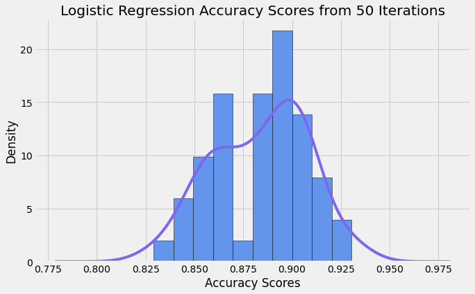

```python
plt.style.use('fivethirtyeight')
plt.figure(figsize = (10, 6))
plt.hist(LR_accuracy_scores, density = True, **kwargs_hist) # used the **kwargs trick to pass args
LR_accuracy_scores.plot(**kwargs_kde) # used the **kwargs trick to pass args
plt.title(f'Logistic Regression Accuracy Scores from {LR_iterations} Iterations')
plt.xlabel('Accuracy Scores')
plt.show()
```

# Finishing Up ML: Making Our Predictions Vis

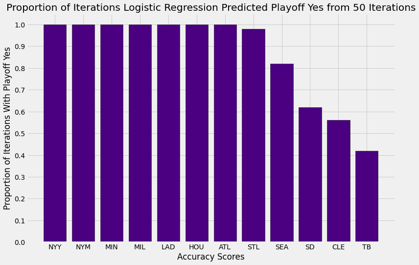

```python
plt.style.use('fivethirtyeight')
plt.figure(figsize = (12, 8))
plt.bar(range(len(LR_predictions)), LR_predictions, **kwargs_bar)
plt.title(f'Proportion of Iterations Logistic Regression Predicted Playoff Yes from {LR_iterations} Iterations')
plt.xlabel('Accuracy Scores')
plt.ylabel('Proportion of Iterations With Playoff Yes')
plt.xticks(range(len(LR_predictions)), LR_predictions.index.map(MLB_abr_map)) # setting the x-labels as teams
plt.yticks(np.arange(0, 1.1, step = 0.1)) # adding more y-labels
plt.show()
```

# Skipping Ahead A Couple Weeks: Medium Article

To present our project, we will be writing an article that summarizes our methods and our findings. Everyone will be required to write some of it.

More specific details will be given when we get there, but I just wanted to give everyone a heads up.

Things you will probably have to discuss in the article:

- Describe which variables from your data set seemed to correlate with/influence playoff status
- Provide some of your EDA visualizations and describe what they are showing
- Discuss one of your ML models and provide the visualizations from that
- Maybe more? We'll see

You might have to refresh yourself on your findings from a few weeks ago, so just keep that in mind

# Interactive Component Discussion

- What would you like to do?
- What tools would you like to use?
- Would you want to have everyone do it individually, or would you want to work in a group with your team?

# Interactive Component Work This Week

I will be reaching out after the meeitng to lay our meeting structure for this week and how we will go about completing the work.

# Things to Do For This Week:

1. Edit your ML code and make visualizations for each model
2. Keep an eye out for Interactive Component instructions and work on the assigned tasks for that
3. Keep and eye our for the When2Meet (maybe)
4. Enjoy your weekend!

Use this week to catch up and get a head start on the interactive component before more new work is assigned. As always, reach out to me with help or questions. It **never** feels like a waste of time to text or meet with you guys.